# Decision Tree Mei 2026

Kode ringkas dan jawaban soal (a)–(d)

2026-10-07

Simpan file di working directory R dengan nama aslinya, `dataSoal2_dataOhlsson_Analitika Data Mei 2026.xlsx`, agar kode baca data di bawah langsung jalan.

Data soal Mei 2026 (Excel) · 2.6 MB

**Cara menjalankan:** letakkan Rmd dan Excel terlampir dalam folder yang sama, buka Rmd di RStudio, lalu klik **Knit**. Jika nama Excel berbeda, ubah nama pada `read_excel()`.

**Dua jenis hasil:** bagian 1 membuat output latihan dari Excel. Bagian 2 menjawab soal berdasarkan **Gambar 4–7 pada PPT**. Seed, pembagian data, dan parameter model asli tidak disediakan, sehingga hasil latihan tidak harus sama dengan gambar soal. Pilihan latihan di sini: training 70%, testing 30%, seed 123, dan kedalaman pohon maksimal 3.

# 1. Kode minimum untuk membuat output

## 1.1. Library dan data

Nama paket pohonnya adalah **`rpart`**. Instalasi cukup sekali melalui Console jika paket belum tersedia.

```r
install.packages(c("readxl", "rpart", "rpart.plot", "caret",
                   "ggplot2", "pROC", "rmarkdown"))
```

```r
library(readxl)
library(rpart)
library(rpart.plot)
library(caret)
library(ggplot2)
library(pROC)
```

```r
data <- read_excel("dataSoal2_dataOhlsson_Analitika Data Mei 2026.xlsx")
data$Status <- factor(ifelse(data$antskad > 0, "Claim", "NoClaim"),
                      levels = c("NoClaim", "Claim"))

data <- data[, c("agarald", "kon", "zon", "mcklass", "fordald",
                 "bonuskl", "duration", "Status")]
data <- na.omit(data)
data[c("kon", "zon", "mcklass", "bonuskl")] <-
  lapply(data[c("kon", "zon", "mcklass", "bonuskl")], factor)

table(data$Status)
```

```
##
## NoClaim   Claim
##   63926     652
```

`Claim` berarti `antskad > 0`. `antskad` dan `skadkost` dikeluarkan dari prediktor karena keduanya memuat informasi kejadian/biaya klaim yang hendak diprediksi (*data leakage*).

Data awal berisi **64.628 baris**. Kode menghapus **50 baris** yang memiliki `zon` kosong, sehingga tersisa **64.578 baris: 63.926 NoClaim dan 652 Claim**. Kode kategori dijadikan faktor agar dapat dipisahkan sebagai kelompok seperti pada pohon soal. Nilai lain dipertahankan karena soal tidak memberikan aturan pembersihan tambahan.

`duration` dipakai mengikuti gambar soal. Untuk prediksi sebelum kejadian, variabel ini hanya boleh dipakai jika durasi paparan yang dimaksud sudah diketahui saat prediksi.

## 1.2. Pisahkan training dan testing

```r
set.seed(123)
id <- createDataPartition(data$Status, p = 0.7, list = FALSE)
train <- data[id, ]
test <- data[-id, ]
```

`createDataPartition()` menjaga proporsi kelas pada pembagian data. Data testing tetap memakai distribusi kelas aslinya.

## 1.3. Undersampling dan distribusi kelas (seperti Gambar 4)

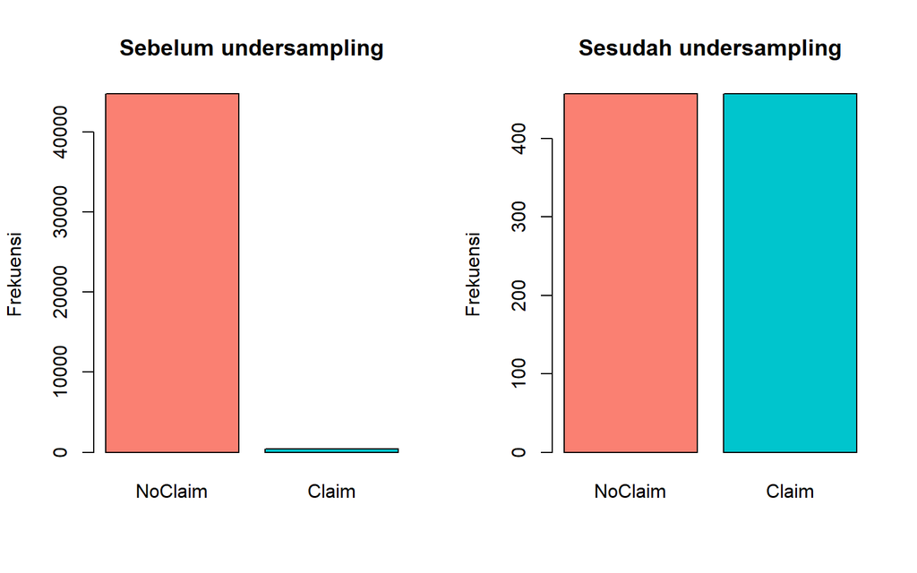

```r
set.seed(123)
train_balance <- downSample(train[, 1:7], train$Status,
                            yname = "Status")

par(mfrow = c(1, 2))
barplot(table(train$Status), main = "Sebelum undersampling",
        col = c("salmon", "turquoise3"), ylab = "Frekuensi")
barplot(table(train_balance$Status), main = "Sesudah undersampling",
        col = c("salmon", "turquoise3"), ylab = "Frekuensi")
```

```r
par(mfrow = c(1, 1))
```

`downSample()` mengambil sebagian NoClaim secara acak sampai jumlahnya sama dengan Claim. **Lakukan setelah split dan hanya pada training**, supaya evaluasi tetap mencerminkan kelangkaan klaim pada data asal.

## 1.4. Decision tree (seperti Gambar 5)

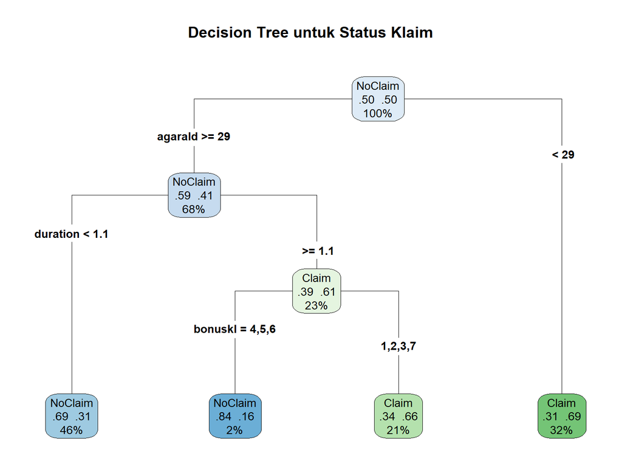

```r
model <- rpart(Status ~ ., data = train_balance, method = "class",
               control = rpart.control(cp = 0.01, maxdepth = 3))
rpart.plot(model, type = 4, extra = 104, fallen.leaves = TRUE,
           main = "Decision Tree untuk Status Klaim")
```

`method = "class"` membuat pohon klasifikasi. `cp` mengendalikan syarat perbaikan untuk menambah split; nilai lebih besar cenderung menghasilkan pohon lebih sederhana. `maxdepth = 3` membatasi kedalaman agar pohon mudah dibaca. Pengaturan ini dipilih untuk latihan, bukan hasil tuning atau parameter asli soal.

Dalam kotak node: baris pertama adalah kelas prediksi, dua angka berikutnya adalah proporsi **NoClaim lalu Claim**, dan persentase paling bawah adalah bagian data training seimbang yang masuk ke node. Proporsi tersebut bukan estimasi langsung peluang klaim pada populasi asal setelah undersampling.

```r
sort(model$variable.importance, decreasing = TRUE)
```

```
##   agarald  duration   bonuskl
## 29.456499 25.565656  9.502332
```

Daftar ini memberi ukuran importance model latihan. Pembacaan root menjelaskan pemisahan pertama; peringkat importance keseluruhan perlu dilihat dari output ini.

## 1.5. Confusion matrix dan metrik (seperti Gambar 6)

```r
pred <- predict(model, test, type = "class")
cm <- confusionMatrix(pred, test$Status, positive = "Claim",
                       mode = "everything")
cm
```

```
## Confusion Matrix and Statistics
##
##           Reference
## Prediction NoClaim Claim
##    NoClaim   12469    63
##    Claim      6708   132
##
##                Accuracy : 0.6505
##                  95% CI : (0.6437, 0.6572)
##     No Information Rate : 0.9899
##     P-Value [Acc > NIR] : 1
##
##                   Kappa : 0.0183
##
##  Mcnemar's Test P-Value : <2e-16
##
##             Sensitivity : 0.676923
##             Specificity : 0.650206
##          Pos Pred Value : 0.019298
##          Neg Pred Value : 0.994973
##               Precision : 0.019298
##                  Recall : 0.676923
##                      F1 : 0.037527
##              Prevalence : 0.010066
##          Detection Rate : 0.006814
##    Detection Prevalence : 0.353087
##       Balanced Accuracy : 0.663565
##
##        'Positive' Class : Claim
##
```

Urutan yang perlu dihafal: **prediksi dulu, aktual kemudian**. `positive = "Claim"` memastikan recall dan precision dihitung untuk kasus klaim.

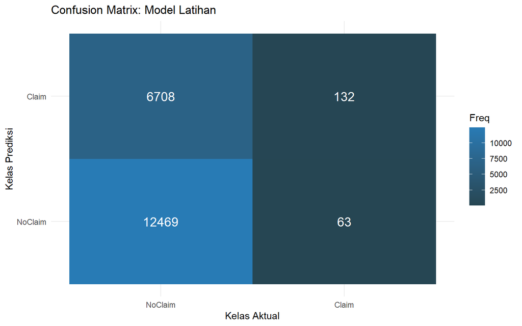

```r
ggplot(as.data.frame(cm$table), aes(Reference, Prediction, fill = Freq)) +
  geom_tile() +
  geom_text(aes(label = Freq), color = "white", size = 5) +
  scale_fill_gradient(low = "#264653", high = "#287BB5") +
  labs(title = "Confusion Matrix: Model Latihan",
       x = "Kelas Aktual", y = "Kelas Prediksi") +
  theme_minimal()
```

## 1.6. ROC dan AUC (seperti Gambar 7)

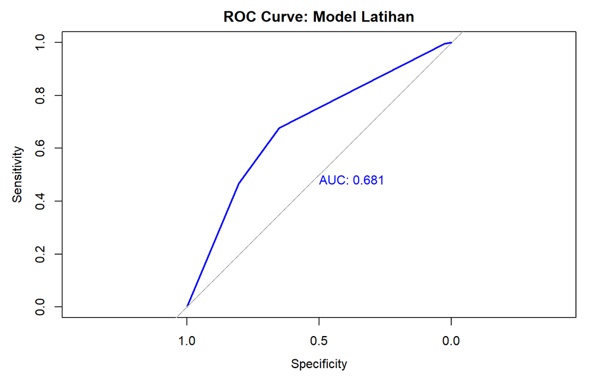

```r
prob <- predict(model, test, type = "prob")[, "Claim"]
roc_model <- roc(test$Status, prob,
                 levels = c("NoClaim", "Claim"), direction = "<")
plot(roc_model, col = "blue", print.auc = TRUE,
     main = "ROC Curve: Model Latihan")
abline(a = 1, b = -1, lty = 2, col = "grey")
```

```r
auc(roc_model)
```

```
## Area under the curve: 0.6812
```

ROC memakai **probabilitas Claim**, bukan label hasil prediksi. Sumbu X di sini adalah specificity yang menurun dari kiri ke kanan. AUC mendekati 1 menunjukkan pemeringkatan yang lebih baik; AUC 0,5 setara pemeringkatan acak. AUC yang tercetak adalah milik **model latihan**, bukan AUC gambar soal.

# 2. Jawaban langsung berdasarkan gambar soal

## (a) Dampak data tidak seimbang dan alternatif undersampling

**Dampak:** NoClaim jauh lebih banyak daripada Claim. Jika model langsung dilatih tanpa penanganan, model cenderung mengutamakan kelas NoClaim sehingga banyak kasus Claim dapat terlewat. Akurasi dapat tampak tinggi meskipun recall Claim rendah. Sebagai ilustrasi, pada confusion matrix soal, menebak semua orang sebagai NoClaim menghasilkan akurasi sekitar **99,00%**, tetapi recall Claim **0%**.

**Alternatif selain undersampling:**

| Alternatif | Cara kerja dan konsekuensi |
| --- | --- |
| Random oversampling | Mengulang observasi Claim pada training. Mempertahankan seluruh NoClaim, tetapi berisiko overfitting pada contoh Claim yang berulang. |
| SMOTE / SMOTENC | Membuat contoh minoritas sintetis. Karena data mengandung prediktor kategori, gunakan metode yang menangani kategori, misalnya SMOTENC. |
| Pembobotan kelas / cost-sensitive learning | Memberi penalti lebih besar saat Claim salah diprediksi sebagai NoClaim, tanpa membuang data mayoritas. |

Menurunkan threshold Claim juga dapat menaikkan recall, dengan konsekuensi lebih banyak false positive. Pilih threshold menggunakan data validasi. Ini mengubah keputusan klasifikasi, bukan menambah atau mengurangi data training.

## (b) Cara pohon membedakan kelas dan profil lebih berisiko

Decision tree membagi data melalui aturan berurutan. Berdasarkan **Gambar 5**, pemisahan pertama memakai **`agarald` (usia pemegang polis) pada batas 34 tahun**. Karena menjadi root, usia paling menonjol dalam pemisahan awal pada gambar. Variabel lanjutan adalah `duration`, `fordald`, `bonuskl`, dan `mcklass`. Gambar saja belum memberi peringkat variable importance secara keseluruhan.

Enam aturan terminal pada gambar adalah:

| Jalur dari root sampai daun | Prediksi | Proporsi Claim pada daun |
| --- | --- | --- |
| `agarald >= 34` dan `duration < 1` | NoClaim | 27% |
| `agarald >= 34`, `duration >= 1`, `bonuskl` termasuk 1, 4, 5, 6 | NoClaim | 36% |
| `agarald >= 34`, `duration >= 1`, `bonuskl` termasuk 2, 3, 7 | Claim | 67% |
| `agarald < 34`, `fordald >= 14`, `mcklass` termasuk 1, 2, 4 | NoClaim | 28% |
| `agarald < 34`, `fordald >= 14`, `mcklass` termasuk 3, 5, 6 | Claim | 55% |
| `agarald < 34` dan `fordald < 14` | Claim | 72% |

**Profil paling berisiko pada gambar:** pemegang polis berusia di bawah 34 tahun dengan usia kendaraan di bawah 14 tahun, karena daun ini mempunyai proporsi Claim tertinggi, **72%**. Kelompok lain yang diprediksi Claim adalah usia minimal 34 tahun dengan `duration >= 1` dan `bonuskl` 2, 3, atau 7, serta kelompok muda dengan kendaraan minimal 14 tahun dan `mcklass` 3, 5, atau 6.

Angka 72% berasal dari training yang diseimbangkan, sehingga **tidak boleh langsung diartikan sebagai peluang klaim 72% pada populasi asli**. Aturan di atas dibaca dari gambar soal; gunakan pohon hasil bagian 1 untuk menafsirkan model latihan.

## (c) Performa model dan metrik yang tepat

Gunakan **Claim sebagai kelas positif**. Angka pada Gambar 6 dibaca sebagai berikut:

| Prediksi / Aktual | NoClaim | Claim |
| --- | --- | --- |
| NoClaim | TN = 11.786 | FN = 55 |
| Claim | FP = 6.731 | TP = 132 |

Kode singkat untuk menghitung metrik langsung dari angka soal:

```r
mat_soal <- matrix(c(11786, 55, 6731, 132), nrow = 2, byrow = TRUE,
                    dimnames = list(Prediksi = c("NoClaim", "Claim"),
                                    Aktual = c("NoClaim", "Claim")))
cm_soal <- confusionMatrix(as.table(mat_soal), positive = "Claim",
                            mode = "everything")
cm_soal
```

```
## Confusion Matrix and Statistics
##
##          Aktual
## Prediksi  NoClaim Claim
##   NoClaim   11786    55
##   Claim      6731   132
##
##                Accuracy : 0.6372
##                  95% CI : (0.6303, 0.6441)
##     No Information Rate : 0.99
##     P-Value [Acc > NIR] : 1
##
##                   Kappa : 0.0183
##
##  Mcnemar's Test P-Value : <2e-16
##
##             Sensitivity : 0.705882
##             Specificity : 0.636496
##          Pos Pred Value : 0.019234
##          Neg Pred Value : 0.995355
##               Precision : 0.019234
##                  Recall : 0.705882
##                      F1 : 0.037447
##              Prevalence : 0.009998
##          Detection Rate : 0.007057
##    Detection Prevalence : 0.366927
##       Balanced Accuracy : 0.671189
##
##        'Positive' Class : Claim
##
```

| Metrik | Nilai dari soal | Interpretasi |
| --- | --- | --- |
| Accuracy | 63,72% | Persentase seluruh prediksi yang benar. |
| Recall / Sensitivity Claim | 70,59% | Menangkap 132 dari 187 kasus klaim aktual. |
| Specificity | 63,65% | Mengenali 11.786 dari 18.517 NoClaim aktual. |
| Precision Claim | 1,92% | Hanya 132 dari 6.863 prediksi Claim yang benar. |
| F1 Claim | 3,74% | Rendah karena precision sangat rendah. |
| Balanced accuracy | 67,12% | Rata-rata recall Claim dan specificity. |

**Penilaian:** model cukup banyak menangkap kasus Claim, tetapi menghasilkan **6.731 false positive** dan masih melewatkan **55 klaim**. Model belum memberikan prediksi Claim yang presisi. Sekitar 98 dari setiap 100 prediksi Claim ternyata NoClaim.

**Metrik yang dipilih:** utamakan **recall Claim** jika tujuan utama adalah mengurangi klaim yang terlewat, tetapi selalu laporkan **precision dan F1** untuk menilai banyaknya alarm palsu. Balanced accuracy membantu menilai kedua kelas secara lebih setara. Gunakan ROC-AUC untuk kemampuan pemeringkatan pada berbagai threshold. Akurasi saja tidak cukup untuk data sangat tidak seimbang ini. PR-AUC juga berguna jika evaluasi tambahan diminta, tetapi tidak diperlukan untuk menjawab gambar yang tersedia.

## (d) Kesimpulan gabungan confusion matrix dan ROC

Confusion matrix menunjukkan kemampuan model pada **satu threshold**: recall Claim 70,59%, tetapi precision hanya 1,92% dan false positive rate sekitar **36,35%**. Kurva ROC pada Gambar 7 terlihat berada di atas garis acak, sehingga model mempunyai kemampuan membedakan kelas lebih baik daripada tebakan acak, tetapi pemisahannya belum kuat.

**Kesimpulan:** model dapat membantu menyaring calon kasus Claim, tetapi prediksi positifnya perlu ditinjau karena alarm palsu sangat banyak. ROC yang berada di atas garis acak tidak menjamin precision tinggi, terutama ketika klaim sangat jarang. Pilihan threshold perlu mempertimbangkan konsekuensi klaim terlewat dan pemeriksaan tambahan pada NoClaim.

**AUC persis pada gambar tidak dapat dihitung dari satu confusion matrix.** PPT tidak menyediakan probabilitas prediksi atau koordinat lengkap kurvanya. Karena itu, jangan menyamakan AUC model latihan dengan AUC pada soal.

# 3. Pola kode yang perlu dihafal

| Kebutuhan | Fungsi utama |
| --- | --- |
| Baca Excel | `read_excel()` |
| Split dengan proporsi kelas terjaga | `createDataPartition()` |
| Undersampling training | `downSample()` |
| Pohon klasifikasi | `rpart(..., method = "class")` |
| Gambar pohon | `rpart.plot()` |
| Prediksi kelas / probabilitas | `predict(..., type = "class")` / `type = "prob"` |
| Confusion matrix dan metrik | `confusionMatrix(..., positive = "Claim")` |
| ROC dan AUC | `roc()` lalu `plot()` dan `auc()` |

**Sumber:** gambar dan pertanyaan dari *Soal Decision Tree Mei 2026(2).pptx*; data dari Excel terlampir. Angka metrik bagian 2 dihitung dari confusion matrix soal. Implementasi fungsi mengacu pada dokumentasi [rpart](https://search.r-project.org/CRAN/refmans/rpart/html/rpart.html), [rpart.plot](https://search.r-project.org/CRAN/refmans/rpart.plot/html/prp.html), [downSample](https://search.r-project.org/CRAN/refmans/caret/html/downSample.html), [confusionMatrix](https://search.r-project.org/CRAN/refmans/caret/html/confusionMatrix.html), dan [pROC](https://search.r-project.org/CRAN/refmans/pROC/html/roc.html).